# Практикум по Вероятности и Статистика с R - Записки

[figure not shown]

## Точкови оценки

Ако имаме наблюдения $x_1, ..., x_n$ над случайна величина $X \sim \mathcal{N}(\mu, \sigma^2)$, то можем да мислим на всяко наблюдение $x_i$ като на наблюдение от случайна величина $X_i$ разпределена като $X$ и $X_i$ са независими. Тоест, имаме независими и еднакво разпределени (н.е.р.) случайни величини $X_1, ..., X_n \overset{distr}{\sim} X \sim \mathcal{N}(\mu, \sigma^2)$, като сме получили по едно наблюдение от всяка. Векторът $(X_1,...,X_n)$ наричаме **случайна извадка**.

Тогава $\bar{x} := \frac{1}{n}\sum_{i=1}^n{x_i}$ е наблюдение от случайната величина $\bar{X} := \frac{1}{n}\sum_{i=1}^n{X_i} \sim \mathcal{N}(\mu, \frac{\sigma^2}{n})$, понеже
$$E[\bar{X}] = E[\frac{1}{n}\sum_{i=1}^n{X_i}]=\frac{1}{n}\sum_{i=1}^n{E[X_i]}=\frac{1}{n}n\mu = \mu\\
Var[\bar{X}]=Var[\frac{1}{n}\sum_{i=1}^n{X_i}] = \frac{1}{n^2}n\sigma^2=\frac{\sigma^2}{n}$$

Забелязваме, че $Var[\bar{X}] \xrightarrow[n\to \infty]{} 0$. Тоест, колкото повече наблюдения имаме, толкова повече $\bar{x}$ има вероятност да е близо до истинския параметър $\mu$, понеже ще е наблюдение от нормално разпределена случайна величина с дисперсия $\frac{\sigma^2}{n}$ и очакване $\mu$.

Можем да наблюдаваме този факт със следната симулация

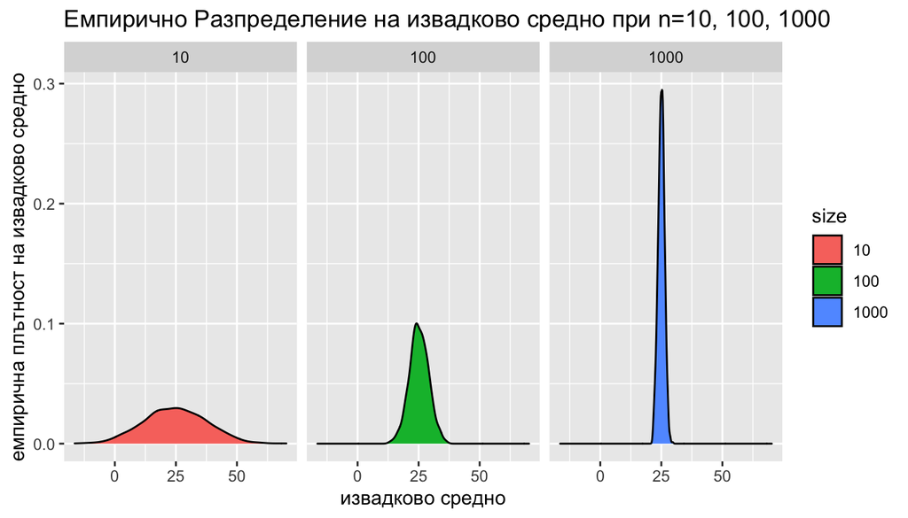

```r
# library("tidyverse")
# library("ggplot2")

# брой извадки които взимаме
n <- 1000

# 1000 пъти взимаме средно на 10, 100 и 1000 наблюдения от N(25, 40^2)
c(10, 100, 1000) %>%
  map(function(size) {
    # Взимаме средното на size на брой наблюдения от N(25, 40^2)
    map(1:n, ~mean(rnorm(size, mean = 25, sd = 40))) %>%
      unlist() %>%
      data.frame(x = ., size = as.character(size))
  }) %>%
  bind_rows() %>%
  ggplot() +
  geom_density(mapping = aes(x = x, fill = size)) +
  facet_wrap(~size) +
  ggtitle("Емпирично Разпределение на извадково средно при n=10, 100, 1000") +
  xlab("извадково средно") +
  ylab("емпирична плътност на извадково средно")
```

Още една визуализация

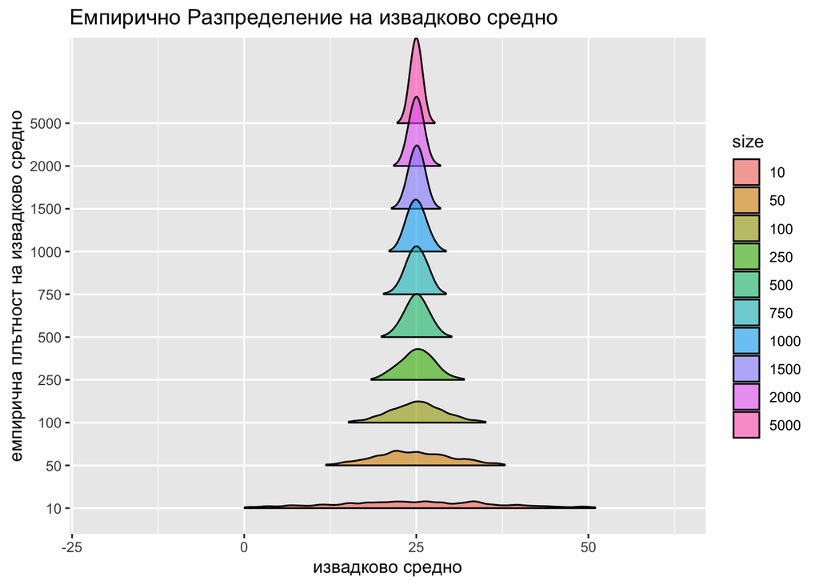

```r
# library("ggridges")

c(10, 50, 100, 250, 500, 750, 1000, 1500, 2000, 5000) %>%
  map(function(size) {
    # Симулираме 1000 на брой извадкови средни от #size наблюдения
    map(1:1000, ~mean(rnorm(size, mean = 25, sd = 40))) %>%
      unlist() %>%
      data.frame(x = ., size = as.factor(size))
  }) %>%
  bind_rows() %>%
  ggplot(mapping = aes(x = x, y = size, fill = size, group = size)) +
  geom_density_ridges2(
    scale = 2, alpha = 0.6, rel_min_height = 0.01,
    # jittered_points = TRUE, position = "raincloud"
  ) +
  ggtitle("Емпирично Разпределение на извадково средно") +
  xlab("извадково средно") +
  ylab("емпирична плътност на извадково средно")
```

$\bar{X}$ наричаме **точкова оценка** за параметъра $\mu$. Това, че $Е(\bar{X}) = \mu$ наричаме **неизместеност** на оценката. Когато една точкова оценка $f_{\theta}(\overrightarrow{X})$ приближава по вероятност своя параметър $\theta$, тоест
$$\lim_{n\to \infty}Pr(|f_{\theta}(\overrightarrow{X}) - \theta| > \epsilon) = 0 \text{ за } \forall \epsilon > 0$$
казваме, че точковата оценка $f_{\theta}(\overrightarrow{X})$ е **асимптотично консистента**. Стандартното отклонение на оценката, обикновено наричаме **стандартна грешка**.

## Интервални Оценки

Така, с вероятност $\gamma$ (**ниво на достоверност**) можем да сме сигурни, че
$$\bar{X} - q \frac{\sigma}{\sqrt{n}} < \mu^? < \bar{X} + q \frac{\sigma}{\sqrt{n}}$$
В **R** за 95% интервал на достоверност, това ще стане по следния начин

```r
n <- 1000
# сигма ни е известно, но мю не ни е и се опитваме да го оценим
known_sd <- 10
x <- rnorm(n, 14.55, known_sd)

emp_mean <- mean(x)
q <- qnorm(0.975)

c(emp_mean - q * known_sd / sqrt(n), emp_mean + q * known_sd / sqrt(n))
```

```
## [1] 14.32594 15.56554
```

В повечето случаи обаче, $\sigma$ не ни е известно. Тогава, ако заместим с извадковото стандартно отклонение **S**, случайната величина $\frac{\bar{X} - \mu}{S/\sqrt{n}}$ има $\mathcal{T}$ разпределение с $n - 1$ степени на свобода. В този случай, трябва просто да използваме квантилите от $\mathcal{T}$ разпределение.

```r
n <- 1000
x <- rnorm(n, 25, 7.654)

emp_mean <- mean(x)
emp_sd <- sd(x)

q <- qt(0.975, df = n - 1)

c(emp_mean - q * emp_sd / sqrt(n), emp_mean + q * emp_sd / sqrt(n))
```

```
## [1] 24.42204 25.42028
```

Или с **t.test** функцията

```r
t.test(x)
```

```
##
##  One Sample t-test
##
## data:  x
## t = 97.98, df = 999, p-value < 2.2e-16
## alternative hypothesis: true mean is not equal to 0
## 95 percent confidence interval:
##  24.42204 25.42028
## sample estimates:
## mean of x
##  24.92116
```

Получената оценка за $\mu$ се нарича **интервална оценка**. Ето как изглеждат интервалите на достоверност при Нормално и $\mathcal{T}$ разпределение за случайната величина Z дефиниране по-горе.

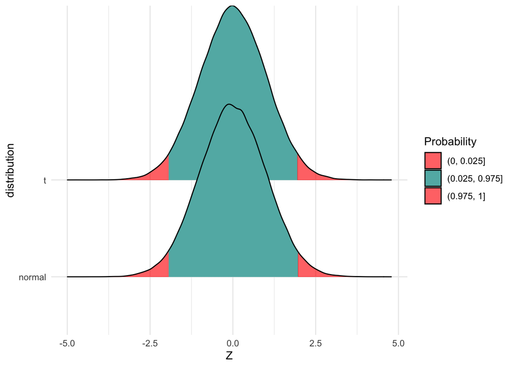

```r
# library("ggridges")

n <- 100000

list("normal" = rnorm(n), "t" = rt(n, 100000 - 1)) %>%
  imap(~data.frame(x = .x, distribution = .y)) %>%
  bind_rows() %>%
  ggplot(aes(x = x, y = distribution, fill = factor(stat(quantile)))) +
  stat_density_ridges(
    geom = "density_ridges_gradient",
    calc_ecdf = TRUE,
    quantiles = c(0.025, 0.975)
  ) +
  scale_fill_manual(
    name = "Probability", values = c("#FF0000A0", "#62b5b2", "#FF0000A0"),
    labels = c("(0, 0.025]", "(0.025, 0.975]", "(0.975, 1]")
  ) +
  xlab("Z") +
  theme_minimal()
```

```r
simulate_t <- function(n, mu, sigma) {
  x <- rnorm(n, mu, sigma)
  b1 <- mean(x) - qt(0.975, df = n - 1) * (sd(x) / sqrt(n))
  b2 <- mean(x) + qt(0.975, df = n - 1) * (sd(x) / sqrt(n))
  between(mu, b1, b2)
}

# да преброим колко елементи са в интервала на достоверност
simulations <- replicate(10000, simulate_t(40, 4, 4))
mean(simulations)
```

```
## [1] 0.9473
```

Виждме, че наистина в около 95% от случаите попадаме в интервала на достоверност.